# Introduction to R Tutorial

Tess Grynoch, tess.grynoch@umassmed.edu

March 2020

## Brief Introduction to R

The term “R” is used to refer to both the programming language and the software that interprets the scripts written using it.

Reasons to use R:

- Easy to reproduce (less pointing and clicking)
- Able to analyze data and create visualizations without altering the data we input into our script regardless of the analysis we run
- Analysis and visualization possibilities are limitless and cross disciplinary boundaries
- Works on all types and sizes of data
- Open source
- Large and welcoming community

## Create a new project

- In JupyterHub, start a new folder for this tutorial and give it a descriptive name.
- It’s good practice to keep all related data, analysis, and text in the same folder in order to use relative paths as opposed to the full path to the file’s location. Another best practice is to create a separate folders for your data, data outputs, and figure outputs. So let’s create a folder named "data" in our tutorial folder and upload the sample data into it and create an empty "data_output" folder and an empty "fig_output" folder.
- Create a new R notebook and rename it using a descriptive file name such as "Intro_R_class_20200311”

Start by giving our notebook a title using a comment which are denoted by a #

```r
#Introduction to R Tutorial March 2020
#Instructor: Tess Grynoch
#Notes by Name

#Comments allow you to add notes as you write your code
```

### Math operations

R has a number of basic built-in functions and arithmetic that make it an excellent calculator.

| + | Add |
| --- | --- |
| - | Subtract |
| * | Multiply |
| / | Divide |
| ^ | Exponents |

R also follows the order of operations denoted by ()

To run a block of code in your notebook, move your cursor to anywhere within the block and press the run button at the top of your notebook or control + enter (On PC) or command + return (On Mac). You'll know that your code block has run when a number appears in the [ ] to the left of the code block.

```r
2+2
```

```
## [1] 4
```

### Comparison operations

Comparison operations return whether something is true or false based on logic/Boolean

```r
#greater than >
4>2
```

```
## [1] TRUE
```

```r
#less than <
2<4
```

```
## [1] TRUE
```

```r
#equals ==
2==4
```

```
## [1] FALSE
```

```r
#does not equal !=
2!=4
```

```
## [1] TRUE
```

```r
#less than or equal to <=
2<=2
```

```
## [1] TRUE
```

```r
#greater than or equal to >=
2>=2
```

```
## [1] TRUE
```

### Variable creation

You can store values in variables using a <- to point to the name you want to use. This allows you use the vaiable name in place of the value. Values that can be turned into variables include numbers, vectors, tables, functions, or plots.

```r
4+2
```

```
## [1] 6
```

```r
y <- 4
y+2
```

```
## [1] 6
```

R is also case sensitive so make sure to spell correctly.

```r
y+2
Y+2 #You will get an error saying object 'Y' not found (Note you can also add a comment to the end of a line of code)
```

You can also overwrite a variable name

```r
y <- 6
y+2
```

```
## [1] 8
```

The right hand side of the assignment can be any valid R expression. The right hand side is fully evaluated before the assignment occurs.

Variable names can contain letters, numbers, underscores and periods. They cannot start with a number nor contain spaces at all. Different people use different conventions for long variable names, these include

- periods.between.words
- underscores_between_words
- camelCaseToSeparateWords What you use is up to you, but *be consistent*.

### Vectors

- character: “a”, “fish”
- numeric (real or decimal): 2, 15.5
- integer: 2L (the L tells R to store this as an integer)
- logical: TRUE, FALSE
- complex: 1+4i (complex numbers with real and imaginary parts)

```r
#two different ways to create vectors
1:5
```

```
## [1] 1 2 3 4 5
```

```r
c(1,2,3,4,5)
```

```
## [1] 1 2 3 4 5
```

```r
x <- 1:5 #we'll assign this vector as the variable x
```

You may not of realized it, but we just used our first function. c denotes concatenate in R. To find out more about any function or library, you can put a question mark in front of the function or library name and run the line to get the help documentation which includes the arguments the function accepts and examples of function use.

```r
?c
```

You can also apply math operations and functions to vectors

```r
2*x
```

```
## [1]  2  4  6  8 10
```

Caution that, if you add a character to an integer vector, the whole vector becomes characters.

```r
y <- c(1,2,3,4,"5")
#Use the class function to find out the type of vector you have
class(y)
```

```
## [1] "character"
```

Never fear! You can convert your vector to a different data type

```r
y <- as.numeric(y) #overwriting a variable
```

### Print statements

While viewing a variable in Jupyter Notebooks is as simple as typing the variable and running the block of code, if we are using R through the command line, you can use print statements to view the variable. Print statements are also useful in complicated functions to explicitely state the result.

```r
print(x)
```

```
## [1] 1 2 3 4 5
```

```r
z <- 8/4
print(c('Solution A is',z,'times as strong as solution B'))
```

```
## [1] "Solution A is"                 "2"
## [3] "times as strong as solution B"
```

### Install packages and add libraries

**Note for RDM 102:** The Tidyverse package has already been installed on the JupyterHub server so we do not need to install it. The following instructions are here for your interest.

To expand on what is already available through the basic R package, we need to install additional packages. Today we’ll be using tidyverse which is a collection of R libraries for data science. For more information on the Tidyverse package, visit the [tidyverse website](https://www.tidyverse.org/).

```r
install.packages("tidyverse")
```

**[RDM 102 continue here]**

Once we install the package, we need to tell it which libraries we will be using

```r
library(tidyverse)
```

### Reading files into R

To use data in out R Notebook we must first read it into the environment and assign it a variable name.

```r
sample <- read.csv("data/sample.csv")
```

I’ve used the relative path to the file above but if I were to use the full destination name it would look something like “C://Users/grynochc/Desktop/Intro-R-class-20191209/Data/sample.csv”

### Data exploration and exploratory statistics

Once you bring your data into your R Notebook, one of the first things you should do is get oriented to it. Even if you collected the data yourself or are already familiar with the data in its original format. I recommend running through some basic functions and exploratory statistics to check how the data was imported and ensure that there are no unexpected surprises. You can also view the whole dataset by opening the file in JupyterHub but this is not always useful with large datasets and I also don’t like moving between tabs.

```r
head(sample)
```

```
##       ID Gender      Group BloodPressure  Age Aneurisms_q1 Aneurisms_q2
## 1 Sub001      m    Control           132 16.0          114          140
## 2 Sub002      m Treatment2           139 17.2          148          209
## 3 Sub003      m Treatment2           130 19.5          196          251
## 4 Sub004      f Treatment1           105 15.7          199          140
## 5 Sub005      m Treatment1           125 19.9          188          120
## 6 Sub006      M Treatment2           112 14.3          260          266
##   Aneurisms_q3 Aneurisms_q4
## 1          202          237
## 2          248          248
## 3          122          177
## 4          233          220
## 5          222          228
## 6          320          294
```

```r
tail(sample)
```

```
##         ID Gender      Group BloodPressure  Age Aneurisms_q1 Aneurisms_q2
## 95  Sub095      m    Control           108 13.6          111          118
## 96  Sub096      m    Control           102 14.6          148          132
## 97  Sub097      F Treatment2            90 19.6          141          196
## 98  Sub098      m Treatment1           133 17.0          193          112
## 99  Sub099      M Treatment2            83 16.2          130          226
## 100 Sub100      M Treatment1           122 18.4          126          157
##     Aneurisms_q3 Aneurisms_q4
## 95           173          191
## 96           200          194
## 97           322          273
## 98           123          181
## 99           286          281
## 100          129          160
```

```r
str(sample) #gives class and head of each column/variable
```

```
## 'data.frame':    100 obs. of  9 variables:
##  $ ID           : Factor w/ 100 levels "Sub001","Sub002",..: 1 2 3 4 5 6 7 8 9 10 ...
##  $ Gender       : Factor w/ 4 levels "f","F","m","M": 3 3 3 1 3 4 1 3 3 1 ...
##  $ Group        : Factor w/ 3 levels "Control","Treatment1",..: 1 3 3 2 2 3 1 3 3 1 ...
##  $ BloodPressure: int  132 139 130 105 125 112 173 108 131 129 ...
##  $ Age          : num  16 17.2 19.5 15.7 19.9 14.3 17.7 19.8 19.4 18.8 ...
##  $ Aneurisms_q1 : int  114 148 196 199 188 260 135 216 117 188 ...
##  $ Aneurisms_q2 : int  140 209 251 140 120 266 98 238 215 144 ...
##  $ Aneurisms_q3 : int  202 248 122 233 222 320 154 279 181 192 ...
##  $ Aneurisms_q4 : int  237 248 177 220 228 294 245 251 272 185 ...
```

```r
names(sample) #column names
```

```
## [1] "ID"            "Gender"        "Group"         "BloodPressure"
## [5] "Age"           "Aneurisms_q1"  "Aneurisms_q2"  "Aneurisms_q3"
## [9] "Aneurisms_q4"
```

```r
dim(sample) #dimensions
```

```
## [1] 100   9
```

We can also examine a particular column by using $ColumnName to call that column.

```r
sample$Age
```

```
##   [1] 16.0 17.2 19.5 15.7 19.9 14.3 17.7 19.8 19.4 18.8 14.8 15.3 16.5 12.6
##  [15] 14.3 15.9 18.4 18.3 15.4 14.3 12.7 15.4 17.2 17.3 16.7 19.6 15.0 16.1
##  [29] 17.6 18.6 18.3 16.7 12.5 14.3 19.7 17.6 17.0 12.2 15.1 17.7 19.0 14.7
##  [43] 15.2 15.3 12.9 18.4 18.1 15.6 19.5 13.5 13.5 13.7 18.7 12.2 16.9 19.5
##  [57] 12.1 17.0 19.2 14.7 20.0 14.1 14.7 16.6 15.0 15.0 13.8 14.8 19.1 18.9
##  [71] 17.7 17.4 15.5 13.1 12.2 17.0 17.7 19.5 19.5 12.8 17.6 17.7 14.2 19.2
##  [85] 16.0 15.2 17.6 17.6 15.1 17.8 16.2 16.6 19.1 17.2 13.6 14.6 19.6 17.0
##  [99] 16.2 18.4
```

R has a number of built in statistical functions and these can be further extended with specific libraries.

```r
mean(sample$Age)
```

```
## [1] 16.42
```

```r
min(sample$Age)
```

```
## [1] 12.1
```

```r
max(sample$Age)
```

```
## [1] 20
```

```r
median(sample$Age)
```

```
## [1] 16.65
```

Instead of running these basic statistics for each column, we can run a summary:

```r
summary(sample)
```

```
##        ID     Gender        Group    BloodPressure        Age
##  Sub001 : 1   f:35   Control   :30   Min.   : 62.0   Min.   :12.10
##  Sub002 : 1   F: 4   Treatment1:35   1st Qu.:107.5   1st Qu.:14.78
##  Sub003 : 1   m:46   Treatment2:35   Median :117.5   Median :16.65
##  Sub004 : 1   M:15                   Mean   :118.6   Mean   :16.42
##  Sub005 : 1                          3rd Qu.:133.0   3rd Qu.:18.30
##  Sub006 : 1                          Max.   :173.0   Max.   :20.00
##  (Other):94
##   Aneurisms_q1    Aneurisms_q2    Aneurisms_q3    Aneurisms_q4
##  Min.   : 65.0   Min.   : 80.0   Min.   :105.0   Min.   :116.0
##  1st Qu.:118.0   1st Qu.:131.5   1st Qu.:182.5   1st Qu.:186.8
##  Median :158.0   Median :162.5   Median :217.0   Median :219.0
##  Mean   :158.8   Mean   :168.0   Mean   :219.8   Mean   :217.9
##  3rd Qu.:188.0   3rd Qu.:196.8   3rd Qu.:248.2   3rd Qu.:244.2
##  Max.   :260.0   Max.   :283.0   Max.   :323.0   Max.   :315.0
##
```

### Dataframe basics

Just as in other programs such as Excel and Python, dataframes are navigated using rows and column numbers. In R the notation is [rows, columns]. Leaving the rows blank will bring back all rows and leaving the columns blank will bring back all columns. (Note: counting starts at 1, not 0 for those familiar with Python) For example, if I wanted to view the 4th row:

```r
sample[4,]
```

```
##       ID Gender      Group BloodPressure  Age Aneurisms_q1 Aneurisms_q2
## 4 Sub004      f Treatment1           105 15.7          199          140
##   Aneurisms_q3 Aneurisms_q4
## 4          233          220
```

We can also call a single datapoint using the same technique

```r
sample[4,3]
```

```
## [1] Treatment1
## Levels: Control Treatment1 Treatment2
```

Or we can call a section of datapoints

```r
sample[1:4,c(3, 5)]
```

```
##        Group  Age
## 1    Control 16.0
## 2 Treatment2 17.2
## 3 Treatment2 19.5
## 4 Treatment1 15.7
```

### Data cleaning

We noticed that there were some capital M and F in the gender column. To ensure accurate analysis we want to turn those into small m and f to match the majority of the cells. Let’s start with cleaning up the Ms and I’m going to break down the operation into its components

```r
sample[sample$Gender=='M', ] #gives me all the rows with Gender M
```

```
##         ID Gender      Group BloodPressure  Age Aneurisms_q1 Aneurisms_q2
## 6   Sub006      M Treatment2           112 14.3          260          266
## 26  Sub026      M Treatment1           123 19.6          115          160
## 27  Sub027      M Treatment2           126 15.0          128          249
## 39  Sub039      M Treatment1           113 15.1          132          137
## 47  Sub047      M    Control           125 18.1          192          141
## 48  Sub048      M    Control            99 15.6          178          180
## 64  Sub064      M Treatment1           149 16.6          189          101
## 69  Sub069      M Treatment2           148 19.1          222          199
## 77  Sub077      M Treatment1           151 17.7          168          184
## 78  Sub078      M Treatment1           121 19.5          118          170
## 79  Sub079      M Treatment1           116 19.5          169          114
## 82  Sub082      M Treatment1            62 17.7          188          108
## 83  Sub083      M Treatment2           124 14.2          169          168
## 99  Sub099      M Treatment2            83 16.2          130          226
```

[output cut: 17 more lines]

```r
sample[sample$Gender=='M', ]$Gender #isolates the gender column of those rows
```

```
##  [1] M M M M M M M M M M M M M M M
## Levels: f F m M
```

```r
sample[sample$Gender=='M', ]$Gender <- 'm' #replace with small m (This is our final operation)
#let's check that it worked
summary(sample$Gender)
```

```
##  f  F  m  M
## 35  4 61  0
```

Run the same operation for the Fs

```r
sample[sample$Gender=='F', ]$Gender <- 'f'
#let's check that it worked
summary(sample$Gender)
```

```
##  f  F  m  M
## 39  0 61  0
```

### Writing files from R

To save the cleaning that we performed on the data, we can export the new sample dataframe as a file

```r
write.csv(sample, "./data_output/sample_v2.csv")
```

### Basic plots

ggplot2 comes as part of tidyverse and can be used to create a number of different plots. Today we’ll cover a couple of basic ones, bar charts and dot plots, but the premise behind building a chart in ggplot is the same for all charts.

#### Bar chart

With any ggplot chart, you start with what data you will be using.

```r
ggplot(data=sample)
```

Next, we’ll define our plot area (mapping) using the aesthetic (aes) function. This generates a blank plot.

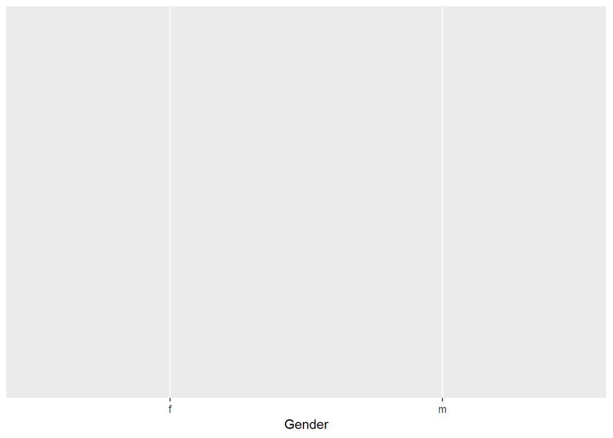

```r
ggplot(data=sample, mapping=aes(x=Gender))
```

We add the various elements to the chart as geoms with a + symbol on the previous line which will automatically indent the next line to keep all our code in a block to run together.

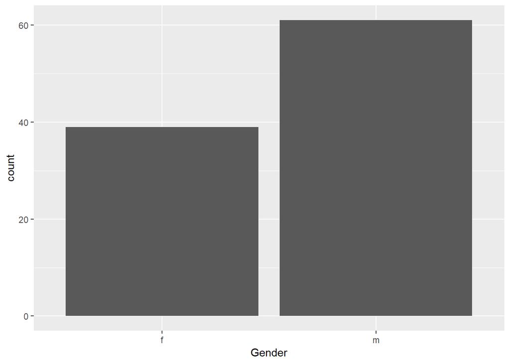

```r
ggplot(data=sample, mapping=aes(x=Gender))+
  geom_bar()
```

The mapping can also be assigned to a particular geom

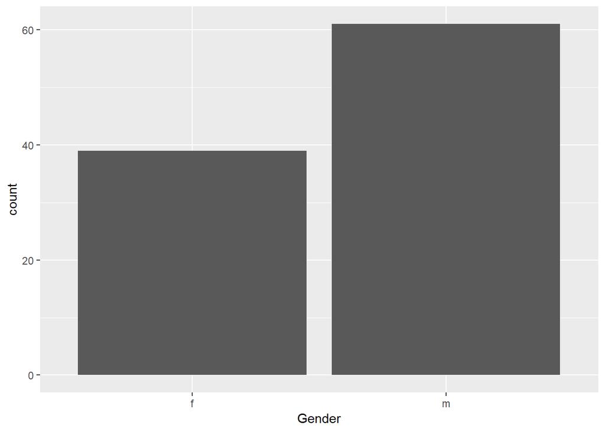

```r
ggplot(data=sample)+
  geom_bar(mapping=aes(x=Gender))
```

You can find out the other arguments and aesthetics that can be used in the geom by viewing the help documentation

```r
?geom_bar
```

For example, we can adjust the width of the columns

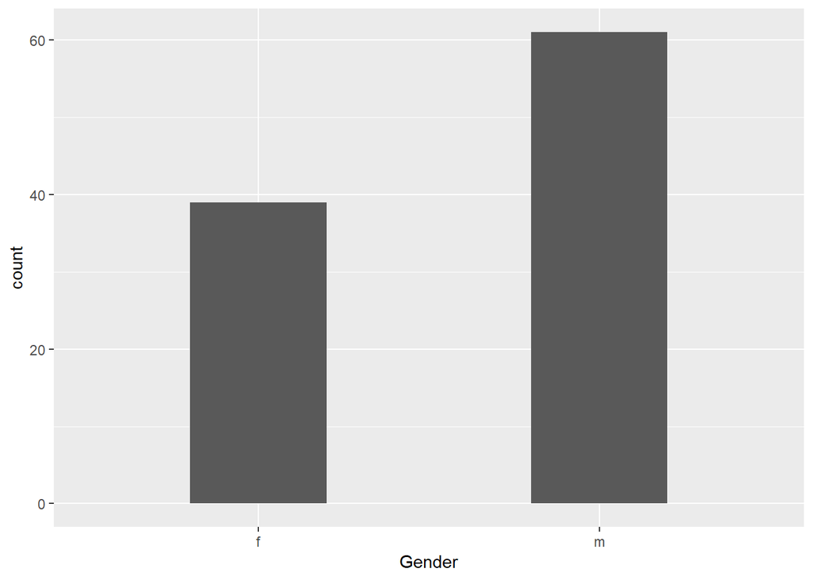

```r
ggplot(data=sample, mapping=aes(x=Gender))+
  geom_bar(width=0.4)
```

**Dot plot**

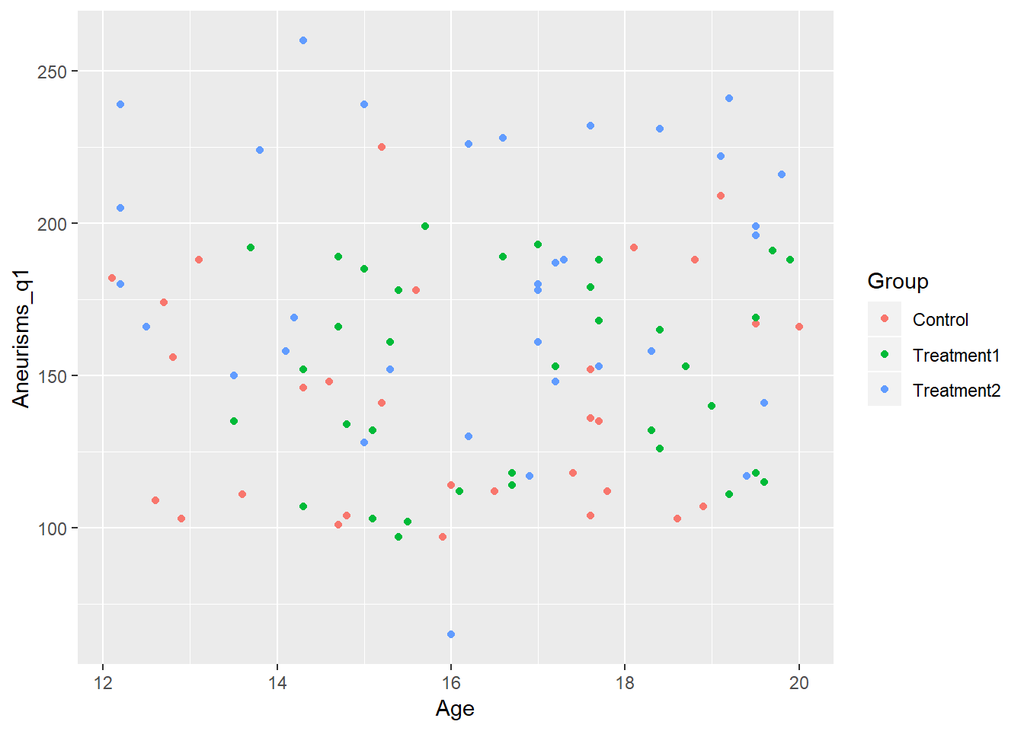

```r
ggplot(data=sample, mapping=aes(x=Age, y=Aneurisms_q1))+
  geom_point(aes(colour=Group))
```

```r
?geom_point
```

```r
q1results <- ggplot(data=sample, mapping=aes(x=Age, y=Aneurisms_q1))+
  geom_point(aes(colour=Group))
```

To save the chart you created use the ggsave function

```r
ggsave("./outputs/q1results.png", q1results)
```

## Further resources for learning R

- [R for Data Science](https://r4ds.had.co.nz/) by Hadley Wickham & Garrett Grolemund
- [Software Carpentry Lessons](https://software-carpentry.org/lessons/)
- [Data Carpentry Lessons](https://datacarpentry.org/lessons/)

Materials from a number of different sources were used in the creation of this class including:

- The Carpentries’ (previously Data Carpentry’s) R for Social Scientists used under the CC-BY 4.0 license.
- The Carpentries’ (previously Software Carpentry) Programming with R used under the CC-BY 4.0 license.
- The Carpentries’ (previously Software Carpentry) R for Reproducible Scientific Analysis used under the the CC-BY 4.0 license.
- R Course by Nick Hathaway as part of the UMMS Bootstrappers Courses  
  This work is licensed under a [Creative Commons Attribution 4.0 International License](http://creativecommons.org/licenses/by/4.0/) by Tess Grynoch